# Project 3 607

Maryluz Cruz

10/13/2019

## Text Analysis of Simplyhired, ai-job.net, and Monster

After all of the Data has been scraped from the Job websites and turned into .csv’s, next we have to read in the .csv file and merge them together and then prepare them for text analysis.

#Load packages

```r
require(dplyr)
require(rvest)
require(stringr)
require(tm)
require(SnowballC)
require(tidytext)
require(stringr)
require(textdata)
require(tidyverse)
```

```r
require(ggplot2)
require(wordcloud)
require(widyr)
require(igraph)
require(ggraph)
require(kableExtra)
```

Since all the comlumn names were different the column names were changed so that they all can be the same when we merge the three databases different databases.

##Read in .csv of SimplyHired

```r
ltcancel<-read.csv("https://raw.githubusercontent.com/ltcancel/Project3/master/SimplyHiredJobs.csv", stringsAsFactors = FALSE, fileEncoding="latin1")
colnames(ltcancel)<-c("Position", "Company","Location","Salary","URL","Job_Description")
str(ltcancel)
```

```
## 'data.frame':    209 obs. of  6 variables:
##  $ Position       : chr  "Data Scientist, Marketplace \u0096 all levels" "Data Engineer" "Senior Data Scientist" "Ecological Wetland Scientist" ...
##  $ Company        : chr  "Spotify" "Noom Inc." "HVH Precision Analytics" "PS&S" ...
##  $ Location       : chr  "New York, NY" "New York, NY" "New York, NY" "Mineola, NY" ...
##  $ Salary         : chr  "Estimated: $110,000 - $160,000 a year" "Estimated: $73,000 - $96,000 a year" "Estimated: $110,000 - $140,000 a yearSimply Apply" "Estimated: $54,000 - $66,000 a year" ...
##  $ URL            : chr  "https://www.simplyhired.com/job/-q6yR-atece9p8LQvm2yP8xIX3VcYfRC9wsdPgSS0nWHIG3f2EZOxA?q=data+scientist" "https://www.simplyhired.com/job/pg680lk5W0WVpIIE7QQXRgEim6bP-NKuilb64EfQF80SDIp_X1ufSA?q=data+scientist" "https://www.simplyhired.com/job/YPL5f6DfJcFxTqZiKpIW3UWlZ0b…
##  $ Job_Description: chr  "Marketplace is the home for Spotify\u0092s music industry products, such as Spotify for Artists, Spotify Label "| __truncated__ "At Noom, we use scientifically proven methods to help our users create healthier lifestyles, and manage importa"| __truncated__ "Job Descripti…
```

## Read in .csv of ai-job.net

```r
selshahawy<-read.csv("https://raw.githubusercontent.com/salma71/MSDS_2019/master/Fall2019/aquisition_management_607/project_3/jobs_detailsInfo.csv", stringsAsFactors = FALSE, fileEncoding="latin1")
colnames(selshahawy)<-c("Position", "Company","Location","URL","Job_Description")
str(selshahawy)
```

```
## 'data.frame':    60 obs. of  5 variables:
##  $ Position       : chr  "Data EngineerMongoDB" "Machine Learning EngineerMedium" "Senior Data EngineerManulife" "Research ScientistAllen Institute for Artificial Intelligence (AI2)" ...
##  $ Company        : chr  "MongoDB" "Medium" "Manulife" "Allen Institute for Artificial Intelligence (AI2)" ...
##  $ Location       : chr  "New York City" "San Francisco" "Toronto, ON CA" "Seattle, WA" ...
##  $ URL            : chr  "https://ai-jobs.net/job/data-engineer-40/" "https://ai-jobs.net/job/machine-learning-engineer-64/" "https://ai-jobs.net/job/senior-data-engineer-8/" "https://ai-jobs.net/job/research-scientist-6/" ...
##  $ Job_Description: chr  "MongoDB is growing rapidly and seeking a Data Engineer to be a key contributor to the overall internal data pla"| __truncated__ "At Medium, words matter. We are building the best place for reading and writing on the internetâ\u0080\u0094a p"| __truncated__ "Are you looki…
```

## Read in .csv of Monster

```r
ssufian<-read.csv("https://raw.githubusercontent.com/salma71/DataScience_skills/master/monsterjobs.csv", stringsAsFactors = FALSE, fileEncoding="latin1")
colnames(ssufian)<-c("Position", "Company","Location","Salary","URL","Job_Description")
str(ssufian)
```

```
## 'data.frame':    26 obs. of  6 variables:
##  $ Position       : chr  "Principal Data Scientist (Facilities Analytics)" "Data Scientist" "Lead Data Scientist" "Data Scientist" ...
##  $ Company        : chr  "Northrop Grumman" "Eaton Corporation" "CenturyLink" "CBTS a Cincinnati Bell Company" ...
##  $ Location       : chr  "Redondo Beach, CA" "Eden Prairie, MN" "BROOMFIELD, CO" "Cincinnati, OH" ...
##  $ Salary         : logi  NA NA NA NA NA NA ...
##  $ URL            : chr  "https://job-openings.monster.com/principal-data-scientist-facilities-analytics-redondo-beach-ca-us-northrop-gru"| __truncated__ "https://job-openings.monster.com/data-scientist-eden-prairie-mn-us-eaton-corporation/2577f928-ed07-402e-bfd1-3e8a72ecb61e" "https://job-openin…
##  $ Job_Description: chr  "At Northrop Grumman we develop cutting-edge technology that preserves freedom and advances human discovery. Our"| __truncated__ "Eaton\u0092s Hydraulics division is currently seeking a DataScientist to join our team. This position is based "| __truncated__ "CenturyLink (…
```

## Merge all the .csv’s into one.

Since we only can merge two at at time, we merge the first two .csvs into one. All the column names and rows are not identical so we have to set all = TRUE to make sure that they all merge no matter the number of columns or the number of rows.

```r
twocsv<-merge(ltcancel,selshahawy,all= TRUE)
str(twocsv)
```

```
## 'data.frame':    269 obs. of  6 variables:
##  $ Position       : chr  "2020 Data Science Intern" "2020 Machine Learning Internship â\u0080\u0093 Amazon SearchAmazon.com" "Administrative NP Coordinator - Stroke Program, Bellevue Hospital" "Administrative NP Coordinator - Stroke Program, Bellevue Hospital" ...
##  $ Company        : chr  "Guardian Life Insurance Company" "Amazon.com" "NYU Langone Health" "NYU Langone Medical Center" ...
##  $ Location       : chr  "New York, NY" "Berlin, Germany" "New York, NY" "New York, NY" ...
##  $ URL            : chr  "https://www.simplyhired.com/job/W0oTT9LF3Cfy9OZtnD5FBVyj1P52XNQnt_6JxZW83BvgYoo2zz2uJQ?q=data+scientist" "https://ai-jobs.net/job/2020-machine-learning-internship-amazon-search/" "https://www.simplyhired.com/job/vM0UOOBVm4K93DvY7BZORwTyO-0LDcZSRcQqg55e1Fvxf3gnaooqQw?q=da…
##  $ Job_Description: chr  "2020 Data Science Intern - (19001927)\nDescription\n\nInternship Overview\nOur Internship Program is a paid 10-"| __truncated__ "We are looking for PhD students to join Amazon Search in Berlin for a 3-6 month internship in 2020.Hundreds of "| __truncated__ "NYU School of…
##  $ Salary         : chr  "5d" NA "Estimated: $44,000 - $57,000 a year8d" "Estimated: $40,000 - $57,000 a year8d" ...
```

Here we merge the third .csv and all of the .csv’s are merged together.

```r
allcsv<-merge(twocsv,ssufian, all=TRUE)
str(allcsv)
```

```
## 'data.frame':    295 obs. of  6 variables:
##  $ Position       : chr  "2020 Citizen Data Scientist Internship" "2020 Data Science Intern" "2020 Machine Learning Internship â\u0080\u0093 Amazon SearchAmazon.com" "Administrative NP Coordinator - Stroke Program, Bellevue Hospital" ...
##  $ Company        : chr  "FCA" "Guardian Life Insurance Company" "Amazon.com" "NYU Langone Health" ...
##  $ Location       : chr  "Detroit, MI" "New York, NY" "Berlin, Germany" "New York, NY" ...
##  $ URL            : chr  "https://job-openings.monster.com/2020-citizen-data-scientist-internship-detroit-mi-us-fca/212893769" "https://www.simplyhired.com/job/W0oTT9LF3Cfy9OZtnD5FBVyj1P52XNQnt_6JxZW83BvgYoo2zz2uJQ?q=data+scientist" "https://ai-jobs.net/job/2020-machine-learning-internship-amazon…
##  $ Job_Description: chr  "FCA US LLC College Intern Program offers a unique opportunity for highly motivated, innovative, and inspired in"| __truncated__ "2020 Data Science Intern - (19001927)\nDescription\n\nInternship Overview\nOur Internship Program is a paid 10-"| __truncated__ "We are lookin…
##  $ Salary         : chr  NA "5d" NA "Estimated: $44,000 - $57,000 a year8d" ...
```

Remove columns to make it easier to run.

```r
allcsv2 <-allcsv[c(1,2,5)]
```

## Prepare the csv for text analysis.

This step creates character vectors using corpus

```r
descriptionofjobs = Corpus(VectorSource(allcsv2$Job_Description))

descriptionofjobs = tm_map(descriptionofjobs, content_transformer(tolower))##changes to lower letters
descriptionofjobs= tm_map(descriptionofjobs, content_transformer(gsub), pattern="\\W",replace=" ")
removeURL = function(x) gsub("http^\\s\\s*", "", x)%>%
descriptionofjobs = tm_map(descriptionofjobs, content_transformer(removeURL))

descriptionofjobs=tm_map(descriptionofjobs,removeNumbers) ##Remove numbers
descriptionofjobs=tm_map(descriptionofjobs,removePunctuation)##Punctuation
descriptionofjobs = tm_map(descriptionofjobs, removeWords, stopwords(kind = "english"))##Stopwords
extraStopwords = c(setdiff(stopwords('english'), c("used", "will")), "time", "can", "sex", "role", "new","can", "job", "etc", "one", "looking", "well","use","best","also", "high", "real", "please", "key", "able", "must", "like", "full", "include", "good", "non", "need","plus","day","year", "com", "want", "age","using","sexual", "help","apply", "race", "orientation", "will", "work", "new")

descriptionofjobs = tm_map(descriptionofjobs, removeWords, extraStopwords) ##more stop words or unwanted words
descriptionofjobs = tm_map (descriptionofjobs, stripWhitespace)
```

## Creating the Bag of Words

```r
allwords2<-DocumentTermMatrix(descriptionofjobs)
```

```r
sparsewords = removeSparseTerms(allwords2,.50)
```

## Begin the analysis

Convert into a tidy table

```r
tidywords<-tidy(sparsewords)
tidywords
```

```
## # A tibble: 4,252 x 3
##    document term        count
##    <chr>    <chr>       <dbl>
##  1 1        business        9
##  2 1        computer        1
##  3 1        data           13
##  4 1        development     1
##  5 1        experience      4
##  6 1        knowledge       2
##  7 1        learning        3
##  8 1        machine         2
##  9 1        models          1
## 10 1        opportunity     2
## # … with 4,242 more rows
```

```r
totalwords<-tidywords%>%
  count(term, sort= TRUE)

kable(totalwords) %>%
  kable_styling(full_width = F) %>%
  column_spec(1, bold = T, border_right = F) %>%
  column_spec(1, width = "15em", background = "lightgreen")
```

| term | n |
| --- | --- |
| data | 287 |
| experience | 279 |
| team | 243 |
| science | 218 |
| years | 216 |
| python | 208 |
| skills | 193 |
| business | 189 |
| learning | 185 |
| degree | 175 |
| knowledge | 171 |
| machine | 171 |
| ability | 169 |
| including | 166 |
| development | 160 |
| opportunity | 160 |
| working | 160 |
| computer | 152 |
| models | 152 |
| strong | 152 |
| engineering | 150 |
| related | 148 |
| scientist | 148 |

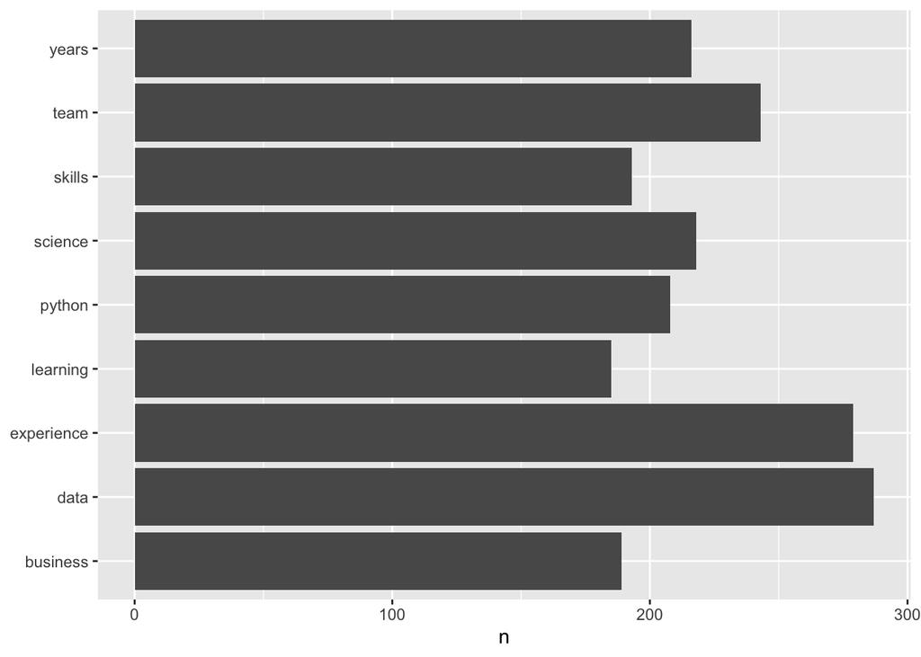

```r
tidywords %>%
  count(term, sort = TRUE) %>%
  filter(n > 180) %>%
  ggplot(aes(term, n)) +
  geom_col() +
  xlab(NULL) +
  coord_flip()
```

```r
summaryofwords<-tidywords %>%
  group_by(term) %>%
  summarize(total = sum(n()))%>%
  arrange(desc(total))

totalwords<-left_join(totalwords, summaryofwords)
```

Frequency of each word inspired by Zipf’s Law

```r
tfrequency <-summaryofwords %>%
  group_by(term)%>%
  mutate(rank= n(), 'frequencyofterm' = n()/total)%>%
  arrange(desc(total))

kable(tfrequency) %>%
  kable_styling(full_width = F) %>%
  column_spec(1, bold = T, border_right = F) %>%
  column_spec(1, width = "15em", background = "cyan")
```

| term | total | rank | frequencyofterm |
| --- | --- | --- | --- |
| data | 287 | 1 | 0.0034843 |
| experience | 279 | 1 | 0.0035842 |
| team | 243 | 1 | 0.0041152 |
| science | 218 | 1 | 0.0045872 |
| years | 216 | 1 | 0.0046296 |
| python | 208 | 1 | 0.0048077 |
| skills | 193 | 1 | 0.0051813 |
| business | 189 | 1 | 0.0052910 |
| learning | 185 | 1 | 0.0054054 |
| degree | 175 | 1 | 0.0057143 |
| knowledge | 171 | 1 | 0.0058480 |
| machine | 171 | 1 | 0.0058480 |
| ability | 169 | 1 | 0.0059172 |
| including | 166 | 1 | 0.0060241 |
| development | 160 | 1 | 0.0062500 |
| opportunity | 160 | 1 | 0.0062500 |
| working | 160 | 1 | 0.0062500 |
| computer | 152 | 1 | 0.0065789 |
| models | 152 | 1 | 0.0065789 |
| strong | 152 | 1 | 0.0065789 |
| engineering | 150 | 1 | 0.0066667 |
| related | 148 | 1 | 0.0067568 |
| scientist | 148 | 1 | 0.0067568 |

Pairing of the words

```r
tidy_word_pairs<-tidywords%>%
  group_by(term) %>%
  arrange(count)

kable(tidy_word_pairs [1:20, 1:3]) %>%
  kable_styling(full_width = F) %>%
  column_spec(1, bold = T, border_right = F) %>%
  column_spec(2, bold = T, border_right = F)%>%
  column_spec(1, width = "10em", background = "yellow")%>%
  column_spec(2, width = "10em", background = "cyan")
```

| document | term | count |
| --- | --- | --- |
| 1 | computer | 1 |
| 1 | development | 1 |
| 1 | models | 1 |
| 1 | related | 1 |
| 1 | science | 1 |
| 2 | ability | 1 |
| 2 | degree | 1 |
| 2 | engineering | 1 |
| 2 | including | 1 |
| 2 | knowledge | 1 |
| 2 | models | 1 |
| 2 | opportunity | 1 |
| 2 | python | 1 |
| 2 | related | 1 |
| 2 | strong | 1 |
| 2 | years | 1 |
| 3 | business | 1 |
| 3 | computer | 1 |
| 3 | degree | 1 |
| 3 | models | 1 |

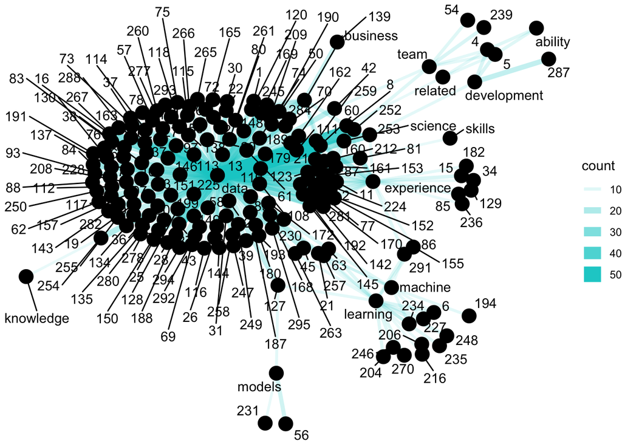

```r
#set.seed(1234)
tidy_word_pairs %>%
  filter(count >= 8) %>%
  graph_from_data_frame() %>%
  ggraph(layout = "fr") +
  geom_edge_link(aes(edge_alpha = count, edge_width = count), edge_colour = "cyan3") +
  geom_node_point(size = 5) +
  geom_node_text(aes(label = name), repel = TRUE,
                 point.padding = unit(0.2, "lines")) +
  theme_void()
```

Correlation of the words

```r
tidywords_cors <- tidywords %>%
  group_by(term) %>%
  filter(n() >= 180) %>%
  pairwise_cor(term, count, sort = TRUE, upper = FALSE)

kable(tidywords_cors) %>%
  kable_styling(full_width = F) %>%
  column_spec(1, bold = T, border_right = F) %>%
  column_spec(2, bold = T, border_right = F)%>%
  column_spec(1, width = "10em", background = "cyan")%>%
  column_spec(2, width = "10em", background = "yellow")
```

| item1 | item2 | correlation |
| --- | --- | --- |
| learning | science | 0.9304842 |
| learning | team | 0.9304842 |
| science | team | 0.8523810 |
| experience | learning | 0.8172253 |
| skills | years | 0.8154762 |
| science | skills | 0.7826238 |
| science | years | 0.7826238 |
| team | years | 0.7826238 |
| experience | science | 0.7604152 |
| business | team | 0.7604152 |
| experience | team | 0.7604152 |
| learning | skills | 0.7282191 |
| learning | years | 0.7282191 |
| skills | python | 0.7126966 |
| python | years | 0.7126966 |
| business | learning | 0.6817494 |
| business | science | 0.6217513 |
| skills | team | 0.6175807 |
| business | experience | 0.6092437 |
| experience | skills | 0.5951190 |
| business | years | 0.5951190 |
| experience | years | 0.5951190 |
| science | python | 0.5577734 |
| python | team | 0.5577734 |
| learning | python | 0.5189993 |
| business | skills | 0.4400880 |
| business | python | 0.4241393 |
| experience | python | 0.4241393 |
| business | data | NaN |
| data | experience | NaN |
| data | learning | NaN |
| data | science | NaN |
| data | skills | NaN |
| data | python | NaN |
| data | team | NaN |
| data | years | NaN |

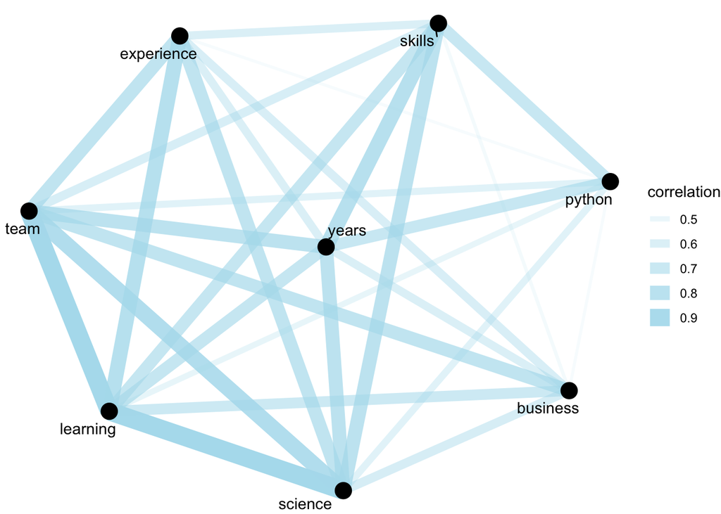

```r
set.seed(1234)
tidywords_cors %>%
  filter(correlation > .3) %>%
  graph_from_data_frame() %>%
  ggraph(layout = "fr") +
  geom_edge_link(aes(edge_alpha = correlation, edge_width = correlation), edge_colour = "lightblue2") +
  geom_node_point(size = 5) +
  geom_node_text(aes(label = name), repel = TRUE,
                 point.padding = unit(0.3, "lines")) +
  theme_void()
```

## WordCloud

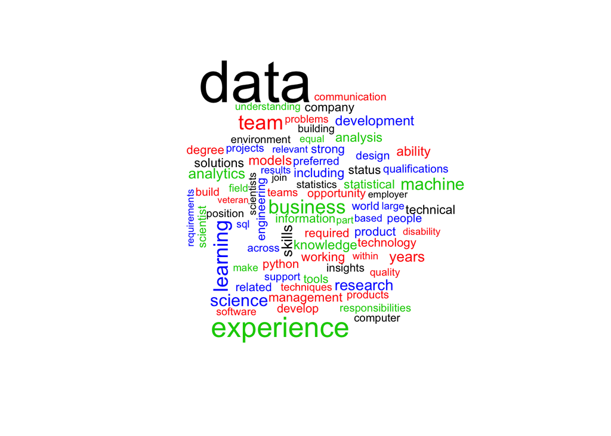

```r
library(wordcloud)
dtm = DocumentTermMatrix(descriptionofjobs)
dtm = removeSparseTerms(dtm, 0.65)
dataset = as.matrix(dtm)
v = sort(colSums(dataset),decreasing=TRUE)
myNames = names(v)
d = data.frame(word=myNames,freq=v)
wordcloud(d$word, colors=c(1:4),random.color=TRUE, d$freq, min.freq=100)
```

## Another Way to merge all of the data tables using the Reduce Function

```r
csv123<-df_list<- list(ltcancel,selshahawy,ssufian)
Reduce(function(d1,d2) merge(d1, d2, by = "Position",all.x=TRUE, all.y = FALSE),df_list)
```

[output not shown]

```r
summary(csv123)
```

```
##      Length Class      Mode
## [1,] 6      data.frame list
## [2,] 5      data.frame list
## [3,] 6      data.frame list
```

## References

1. Text Mining With R https://www.tidytextmining.com/

2.Corpus https://www.rdocumentation.org/packages/tm/versions/0.7-6/topics/Corpus

3.KableExtra https://cran.r-project.org/web/packages/kableExtra/vignettes/awesome_table_in_html.html#overview

4.R Reduce Applys https://blog.zhaw.ch/datascience/r-reduce-applys-lesser-known-brother/

RPubs Link http://rpubs.com/Luz917/project3data607Cruz